# 01 BiocHail – GWAS tutorial from hail.is

Vincent J. Carey, stvjc at channing.harvard.edu

January 14, 2023

# 1 Introduction

This document explores using Hail 0.2 with R via basilisk.

The computations follow the [GWAS tutorial](https://hail.is/docs/0.2/tutorials/01-genome-wide-association-study.html) in the hail documentation. We won’t do all the computations there, and we add some material dealing with R-python interfacing. We’ll note that the actual computations on large data are done in Spark, but we don’t interact directly with Spark at all in this document.

Most of the computations are done via reticulate calls to python; the access to the hail environment is through basilisk. We also take advantage of R markdown’s capacity to execute python code directly. If an R chunk computes `x`, a python chunk can refer to it as `r.x`. If a python chunk computes `r.x`, an R chunk can refer to this value as `x`.

# 2 Acquire a slice of the 1000 genomes genotypes and annotations

In this section we import the 1000 genomes VCF slice distributed by the hail project. `hail_init` uses basilisk, which ensures that a specific version of hail and its dependencies are available in an isolated virtual environment.

```r
library(BiocHail)
library(ggplot2)
```

## 2.1 Initialization, data acquisition, rendering

Here is a curiosity of R-hail interaction. Note that the following chunk computes `mt`, a MatrixTable representation of 1000 genomes data, but our attempt to print it in markdown fails.

```r
hl <- hail_init()
```

```
## + '/home/stvjc/.cache/R/basilisk/1.11.2/0/bin/conda' 'create' '--yes' '--prefix' '/home/stvjc/.cache/R/basilisk/1.11.2/BiocHail/0.99.4/bsklenv' 'python=3.8.13' '--quiet' '-c' 'conda-forge'
```

```
## + '/home/stvjc/.cache/R/basilisk/1.11.2/0/bin/conda' 'install' '--yes' '--prefix' '/home/stvjc/.cache/R/basilisk/1.11.2/BiocHail/0.99.4/bsklenv' 'python=3.8.13'
```

```
## + '/home/stvjc/.cache/R/basilisk/1.11.2/0/bin/conda' 'install' '--yes' '--prefix' '/home/stvjc/.cache/R/basilisk/1.11.2/BiocHail/0.99.4/bsklenv' '-c' 'conda-forge' 'python=3.8.13' 'pandas=1.3.5'
```

```r
mt <- get_1kg(hl)
mt
```

```
## <hail.matrixtable.MatrixTable object at 0x7f928f50c1c0>
```

```r
print(mt$rows()$select()$show(5L)) # limited info
```

We can use the python syntax in a `python` R markdown chunk to see what we want. We use prefix `r.` to find references defined in our R session (compiling the vignette).

```python
r.mt.rows().select().show(5) # python chunk!
```

```
## +---------------+------------+
## | locus         | alleles    |
## +---------------+------------+
## | locus<GRCh37> | array<str> |
## +---------------+------------+
## | 1:904165      | ["G","A"]  |
## | 1:909917      | ["G","A"]  |
## | 1:986963      | ["C","T"]  |
## | 1:1563691     | ["T","G"]  |
## | 1:1707740     | ["T","G"]  |
## +---------------+------------+
## showing top 5 rows
```

The sample IDs:

```python
r.mt.s.show(5)  # python chunk!
```

```
## +-----------+
## | s         |
## +-----------+
## | str       |
## +-----------+
## | "HG00096" |
## | "HG00099" |
## | "HG00105" |
## | "HG00118" |
## | "HG00129" |
## +-----------+
## showing top 5 rows
```

## 2.2 Helper functions

Some methods return data immediately useful in R.

```r
mt$count()
```

```
## [[1]]
## [1] 10961
##
## [[2]]
## [1] 284
```

We can thus define a function `dim` to behave with hail MatrixTable instances in a familiar way, along with some others.

```r
dim.hail.matrixtable.MatrixTable <- function(x) {
  tmp <- x$count()
  c(tmp[[1]], tmp[[2]])
}
dim(mt)
```

```
## [1] 10961   284
```

```r
ncol.hail.matrixtable.MatrixTable <- function(x) {
 dim(x)[2]
}
nrow.hail.matrixtable.MatrixTable <- function(x) {
 dim(x)[1]
}
nrow(mt)
```

```
## [1] 10961
```

These can be useful on their own, or when calling python methods.

## 2.3 Acquiring `column fields`

```r
annopath <- path_1kg_annotations()
tab <- hl$import_table(annopath, impute=TRUE)$key_by("Sample")
```

```python
r.tab.describe()# python chunk!
```

```
## ----------------------------------------
## Global fields:
##     None
## ----------------------------------------
## Row fields:
##     'Sample': str
##     'Population': str
##     'SuperPopulation': str
##     'isFemale': bool
##     'PurpleHair': bool
##     'CaffeineConsumption': int32
## ----------------------------------------
## Key: ['Sample']
## ----------------------------------------
```

```python
r.tab.show(width=100)
```

```
## +-----------+------------+-----------------+----------+------------+---------------------+
## | Sample    | Population | SuperPopulation | isFemale | PurpleHair | CaffeineConsumption |
## +-----------+------------+-----------------+----------+------------+---------------------+
## | str       | str        | str             |     bool |       bool |               int32 |
## +-----------+------------+-----------------+----------+------------+---------------------+
## | "HG00096" | "GBR"      | "EUR"           |    False |      False |                   4 |
## | "HG00097" | "GBR"      | "EUR"           |     True |       True |                   4 |
## | "HG00098" | "GBR"      | "EUR"           |    False |      False |                   5 |
## | "HG00099" | "GBR"      | "EUR"           |     True |      False |                   4 |
## | "HG00100" | "GBR"      | "EUR"           |     True |      False |                   5 |
## | "HG00101" | "GBR"      | "EUR"           |    False |       True |                   1 |
## | "HG00102" | "GBR"      | "EUR"           |     True |       True |                   6 |
## | "HG00103" | "GBR"      | "EUR"           |    False |       True |                   5 |
## | "HG00104" | "GBR"      | "EUR"           |     True |      False |                   5 |
## | "HG00105" | "GBR"      | "EUR"           |    False |      False |                   4 |
## +-----------+------------+-----------------+----------+------------+---------------------+
## showing top 10 rows
```

## 2.4 Adding the sample annotation to the MatrixTable; aggregation

We combine the `tab` defined above, with the MatrixTable instance, usiny python code reaching to R via `r.`.

```python
r.mt = r.mt.annotate_cols(pheno = r.tab[r.mt.s])   # python chunk!
r.mt.col.describe()
```

```
## --------------------------------------------------------
## Type:
##         struct {
##         s: str,
##         pheno: struct {
##             Population: str,
##             SuperPopulation: str,
##             isFemale: bool,
##             PurpleHair: bool,
##             CaffeineConsumption: int32
##         }
##     }
## --------------------------------------------------------
## Source:
##     <hail.matrixtable.MatrixTable object at 0x7f9276de6580>
## Index:
##     ['column']
## --------------------------------------------------------
```

Aggregation methods can be used to obtain contingency tables or descriptive statistics.

First, we get the frequencies of superpopulation membership:

```r
mt$aggregate_cols(hl$agg$counter(mt$pheno$SuperPopulation))
```

```
## $AFR
## [1] 76
##
## $AMR
## [1] 34
##
## $EAS
## [1] 72
##
## $EUR
## [1] 47
##
## $SAS
## [1] 55
```

Then statistics on caffeine consumption:

```r
uu <- mt$aggregate_cols(hl$agg$stats(mt$pheno$CaffeineConsumption))
names(uu)
```

```
##  [1] "annotate" "drop"     "get"      "items"    "keys"     "max"
##  [7] "mean"     "min"      "n"        "select"   "stdev"    "sum"
## [13] "values"
```

```r
uu$mean
```

```
## [1] 4.415493
```

```r
uu$stdev
```

```
## [1] 1.577763
```

# 3 Working with variants; quality assessment

The significance of the aggregation functions is that the computations are performed by Spark, on potentially huge distributed data structures.

Now we aggregate over rows (SNPs). We’ll use python directly:

```python
from pprint import pprint  # python chunk!
snp_counts = r.mt.aggregate_rows(r.hl.agg.counter(r.hl.Struct(ref=r.mt.alleles[0], alt=r.mt.alleles[1])))
pprint(snp_counts)
```

```
## {Struct(ref='A', alt='C'): 454,
##  Struct(ref='A', alt='G'): 1944,
##  Struct(ref='C', alt='T'): 2436,
##  Struct(ref='G', alt='A'): 2387,
##  Struct(ref='G', alt='C'): 112,
##  Struct(ref='T', alt='A'): 79,
##  Struct(ref='T', alt='C'): 1879,
##  Struct(ref='T', alt='G'): 468,
##  Struct(ref='G', alt='T'): 480,
##  Struct(ref='A', alt='T'): 76,
##  Struct(ref='C', alt='A'): 496,
##  Struct(ref='C', alt='G'): 150}
```

## 3.1 A histogram of read depths

Hail uses the concept of ‘entries’ for matrix elements, and each ‘entry’ is a ‘struct’ with potentially many fields.

Here we’ll use R to compute a histogram of sequencing depths over all samples and variants.

```r
p_hist <- mt$aggregate_entries(
     hl$expr$aggregators$hist(mt$DP, 0L, 30L, 30L))
names(p_hist)
```

```
##  [1] "annotate"  "bin_edges" "bin_freq"  "drop"      "get"       "items"
##  [7] "keys"      "n_larger"  "n_smaller" "select"    "values"
```

```r
length(p_hist$bin_edges)
```

```
## [1] 31
```

```r
length(p_hist$bin_freq)
```

```
## [1] 30
```

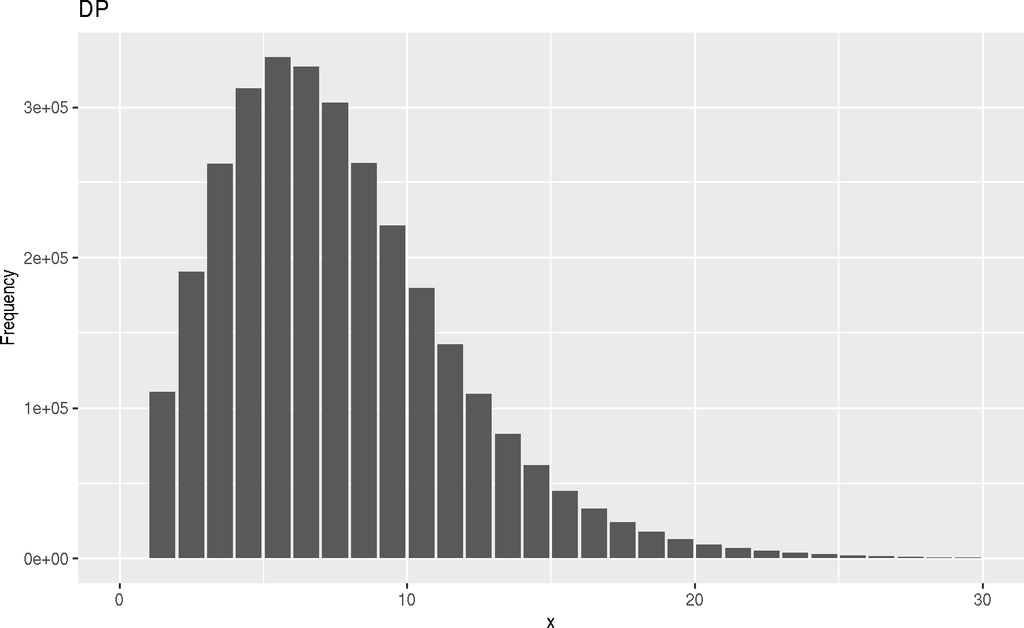

```r
midpts <- function(x) diff(x)/2+x[-length(x)]
dpdf <- data.frame(x=midpts(p_hist$bin_edges), y=p_hist$bin_freq)
ggplot(dpdf, aes(x=x,y=y)) + geom_col() + ggtitle("DP") + ylab("Frequency")
```

An exercise: produce a function `mt_hist` that produces a histogram of measures from any of the relevant VCF components of a MatrixTable instance.

Note also all the aggregators available:

```r
names(hl$expr$aggregators)
```

```
##  [1] "aggregators"         "all"                 "any"
##  [4] "approx_cdf"          "approx_median"       "approx_quantiles"
##  [7] "array_agg"           "array_sum"           "call_stats"
## [10] "collect"             "collect_as_set"      "corr"
## [13] "count"               "count_where"         "counter"
## [16] "downsample"          "explode"             "filter"
## [19] "fold"                "fraction"            "group_by"
## [22] "hardy_weinberg_test" "hist"                "inbreeding"
## [25] "info_score"          "linreg"              "max"
## [28] "mean"                "min"                 "ndarray_sum"
## [31] "product"             "stats"               "sum"
## [34] "take"
```

We’d also note that hail has a [direct interface to ggplot2](https://hail.is/docs/0.2/tutorials/09-ggplot.html).

## 3.2 Quality summaries

A high-level function adds quality metrics to the MatrixTable.

```r
mt <- hl$sample_qc(mt)
```

```python
r.mt.col.describe()  # python!
```

```
## --------------------------------------------------------
## Type:
##         struct {
##         s: str,
##         pheno: struct {
##             Population: str,
##             SuperPopulation: str,
##             isFemale: bool,
##             PurpleHair: bool,
##             CaffeineConsumption: int32
##         },
##         sample_qc: struct {
##             dp_stats: struct {
##                 mean: float64,
##                 stdev: float64,
##                 min: float64,
##                 max: float64
##             },
##             gq_stats: struct {
##                 mean: float64,
##                 stdev: float64,
##                 min: float64,
##                 max: float64
##             },
##             call_rate: float64,
##             n_called: int64,
##             n_not_called: int64,
##             n_filtered: int64,
##             n_hom_ref: int64,
##             n_het: int64,
##             n_hom_var: int64,
##             n_non_ref: int64,
##             n_singleton: int64,
##             n_snp: int64,
##             n_insertion: int64,
##             n_deletion: int64,
##             n_transition: int64,
##             n_transversion: int64,
##             n_star: int64,
##             r_ti_tv: float64,
##             r_het_hom_var: float64,
##             r_insertion_deletion: float64
##         }
##     }
## --------------------------------------------------------
## Source:
##     <hail.matrixtable.MatrixTable object at 0x7f9276debb50>
## Index:
##     ['column']
## --------------------------------------------------------
```

The call rate histogram is given by:

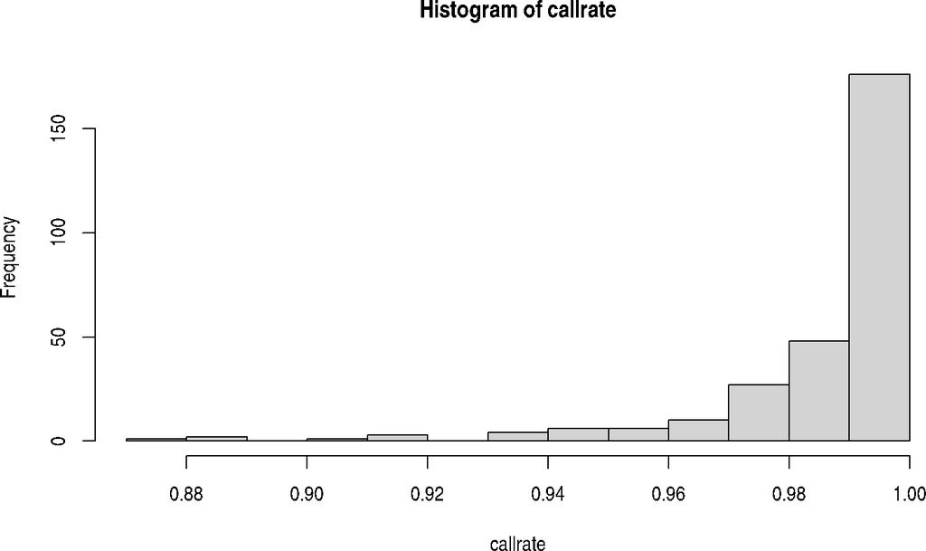

```r
callrate <- mt$sample_qc$call_rate$collect()
hist(callrate)
```

## 3.3 Filtering

### 3.3.1 Sample quality

We’ll use the python code given for filtering, in which per-sample mean read depth and call rate are must exceed (arbitrarily chosen) thresholds.

```python
# python chunk!
r.mt = r.mt.filter_cols((r.mt.sample_qc.dp_stats.mean >= 4) & (r.mt.sample_qc.call_rate >= 0.97))
print('After filter, %d/284 samples remain.' % r.mt.count_cols())
```

```
## After filter, 250/284 samples remain.
```

### 3.3.2 Genotype quality

Again we use the python code for filtering according to

- relative purity of reads underlying homozygous reference or alt calls
- good balance of ref/alt counts for het calls

```python
ab = r.mt.AD[1] / r.hl.sum(r.mt.AD)

filter_condition_ab = ((r.mt.GT.is_hom_ref() & (ab <= 0.1)) |
                        (r.mt.GT.is_het() & (ab >= 0.25) & (ab <= 0.75)) |
                        (r.mt.GT.is_hom_var() & (ab >= 0.9)))

fraction_filtered = r.mt.aggregate_entries(r.hl.agg.fraction(~filter_condition_ab))
print(f'Filtering {fraction_filtered * 100:.2f}% entries out of downstream analysis.')
```

```
## Filtering 3.60% entries out of downstream analysis.
```

```python
r.mt = r.mt.filter_entries(filter_condition_ab)
```

Note that filtering *entries* does not change MatrixTable shape.

```r
dim(mt)
```

```
## [1] 10961   250
```

### 3.3.3 Variant characteristics

Allele frequencies, Hardy-Weinberg equilibrium test results and other summaries are obtained using the `variant_qc` function.

```r
mt = hl$variant_qc(mt)
```

```python
r.mt.row.describe()  #! python
```

```
## --------------------------------------------------------
## Type:
##         struct {
##         locus: locus<GRCh37>,
##         alleles: array<str>,
##         rsid: str,
##         qual: float64,
##         filters: set<str>,
##         info: struct {
##             AC: array<int32>,
##             AF: array<float64>,
##             AN: int32,
##             BaseQRankSum: float64,
##             ClippingRankSum: float64,
##             DP: int32,
##             DS: bool,
##             FS: float64,
##             HaplotypeScore: float64,
##             InbreedingCoeff: float64,
##             MLEAC: array<int32>,
##             MLEAF: array<float64>,
##             MQ: float64,
##             MQ0: int32,
##             MQRankSum: float64,
##             QD: float64,
##             ReadPosRankSum: float64,
##             set: str
##         },
##         variant_qc: struct {
##             dp_stats: struct {
##                 mean: float64,
##                 stdev: float64,
##                 min: float64,
##                 max: float64
##             },
##             gq_stats: struct {
##                 mean: float64,
##                 stdev: float64,
##                 min: float64,
##                 max: float64
##             },
##             AC: array<int32>,
##             AF: array<float64>,
##             AN: int32,
##             homozygote_count: array<int32>,
##             call_rate: float64,
##             n_called: int64,
##             n_not_called: int64,
##             n_filtered: int64,
##             n_het: int64,
##             n_non_ref: int64,
##             het_freq_hwe: float64,
##             p_value_hwe: float64,
##             p_value_excess_het: float64
##         }
##     }
## --------------------------------------------------------
## Source:
##     <hail.matrixtable.MatrixTable object at 0x7f926e1b5040>
## Index:
##     ['row']
## --------------------------------------------------------
```

# 4 GWAS execution

A built-in procedure for testing for association between the (simulated) caffeine consumption measure and genotype will be used.

The following commands eliminate variants with minor allele frequency less than 0.01, along with those with small $p$-values in tests of Hardy-Weinberg equilibrium.

```python
r.mt = r.mt.filter_rows(r.mt.variant_qc.AF[1] > 0.01)
r.mt = r.mt.filter_rows(r.mt.variant_qc.p_value_hwe > 1e-6)
r.mt.count()
```

```
## (7844, 250)
```

## 4.1 Association test for quantitative response

Now we perform a naive test of association. The Manhattan plot generated by hail can be displayed for interaction using bokeh. We comment this out for now; it should be possible to embed the bokeh display in this document but the details are not ready-to-hand.

```python
r.gwas = r.hl.linear_regression_rows(y=r.mt.pheno.CaffeineConsumption,
                                 x=r.mt.GT.n_alt_alleles(),
                                 covariates=[1.0])
# r.pl = r.hl.plot.manhattan(r.gwas.p_value)
# import bokeh
# bokeh.plotting.show(r.pl)
```

```
## 2023-01-14 08:44:38.259 Hail: INFO: linear_regression_rows: running on 250 samples for 1 response variable y,
##     with input variable x, and 1 additional covariate...
```

The “QQ plot” that helps evaluate adequacy of the analysis can be formed using `hl.plot.qq` for very large applications; here we collect the results for plotting in R.

First we estimate $\lambda_{GC}$

```r
pv = gwas$p_value$collect()
x2 = qchisq(1-pv,1)
lam = median(x2, na.rm=TRUE)/qchisq(.5,1)
lam
```

```
## [1] 3.558453
```

And the qqplot:

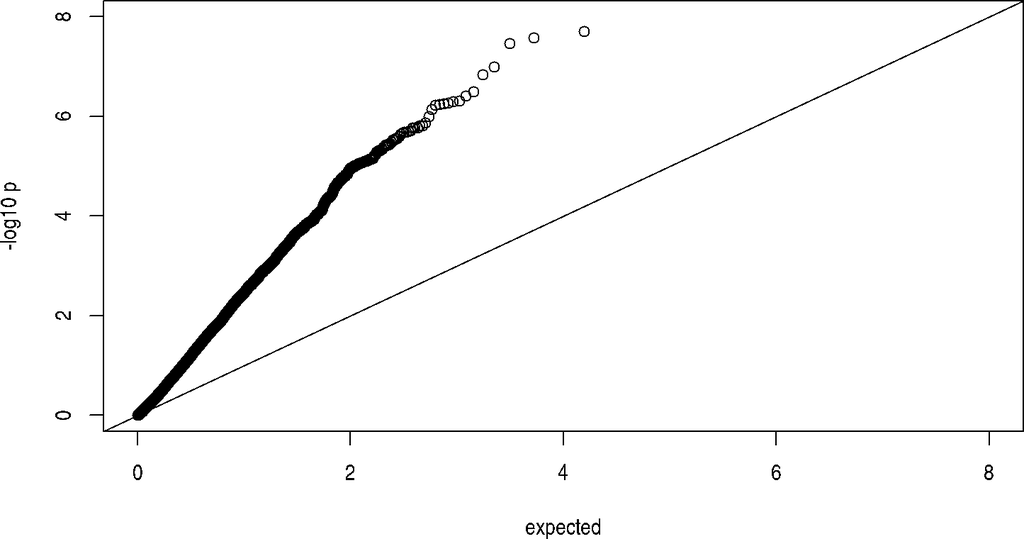

```r
qqplot(-log10(ppoints(length(pv))), -log10(pv), xlim=c(0,8), ylim=c(0,8),
  ylab="-log10 p", xlab="expected")
abline(0,1)
```

There is hardly any point to examining a Manhattan plot in this situation. But let’s see how it might be done. We’ll use igvR to get an interactive and extensible display.

```r
locs <- gwas$locus$collect()
conts <- sapply(locs, function(x) x$contig)
pos <- sapply(locs, function(x) x$position)
library(igvR)
mytab <- data.frame(chr=as.character(conts), pos=pos, pval=pv)
gt <- GWASTrack("simp", mytab, chrom.col=1, pos.col=2, pval.col=3)
igv <- igvR()
setGenome(igv, "hg19")
displayTrack(igv, gt)
```

## 4.2 Evaluating population stratification

An approach to assessing population stratification is provided as `hwe_normalized_pca`. See the hail [methods docs](https://hail.is/docs/0.2/methods/genetics.html#hail.methods.hwe_normalized_pca) for details.

We are avoiding a tuple assignment in the tutorial document.

```python
r.pcastuff = r.hl.hwe_normalized_pca(r.mt.GT)
```

```
## 2023-01-14 08:44:45.066 Hail: INFO: hwe_normalize: found 7836 variants after filtering out monomorphic sites.
## 2023-01-14 08:44:47.475 Hail: INFO: pca: running PCA with 10 components...
```

```python
r.mt = r.mt.annotate_cols(scores=r.pcastuff[1][r.mt.s].scores)
```

We’ll collect the key information and plot.

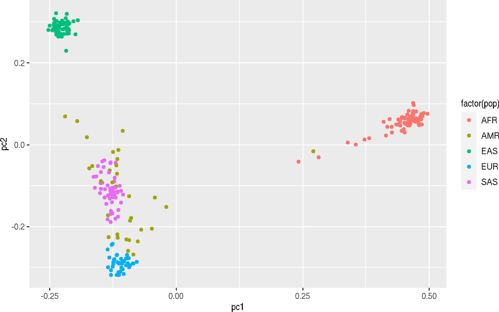

```r
sc <- pcastuff[[2]]$scores$collect()
pc1 = sapply(sc, "[", 1)
pc2 = sapply(sc, "[", 2)
fac = mt$pheno$SuperPopulation$collect()
myd = data.frame(pc1, pc2, pop=fac)
library(ggplot2)
ggplot(myd, aes(x=pc1, y=pc2, colour=factor(pop))) + geom_point()
```

Now repeat the association test with adjustments for population of origin and gender.

```python
r.gwas2 = r.hl.linear_regression_rows(
    y=r.mt.pheno.CaffeineConsumption,
    x=r.mt.GT.n_alt_alleles(),
    covariates=[1.0,r.mt.pheno.isFemale,r.mt.scores[0],
        r.mt.scores[1], r.mt.scores[2]])
```

```
## 2023-01-14 08:45:00.436 Hail: INFO: linear_regression_rows: running on 250 samples for 1 response variable y,
##     with input variable x, and 5 additional covariates...
```

New value of $\lambda_{GC}$:

```r
pv = gwas2$p_value$collect()
x2 = qchisq(1-pv,1)
lam = median(x2, na.rm=TRUE)/qchisq(.5,1)
lam
```

```
## [1] 1.08359
```

A manhattan plot for chr8:

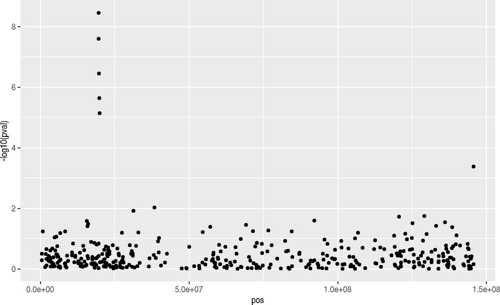

```r
locs <- gwas2$locus$collect()
conts <- sapply(locs, function(x) x$contig)
pos <- sapply(locs, function(x) x$position)
mytab <- data.frame(chr=as.character(conts), pos=pos, pval=pv)
ggplot(mytab[mytab$chr=="8",], aes(x=pos, y=-log10(pval))) + geom_point()
```

# 5 Conclusions

The tutorial document proceeds with some illustrations of arbitrary aggregations. We will skip these for now.

Additional vignettes will address

- A more realistic higher-volume VCF
- Working with UKBB Summary statistics in GCP
  - https://pan.ukbb.broadinstitute.org/docs/hail-format/index.html
- Representing linkage disequilibrium
  - https://pan-dev.ukbb.broadinstitute.org/docs/ld/index.html
- Simulating variant collections using Balding-Nichols
- Simulating variant collections using Pritchard-Stephens-Donnelly
- Connecting genotypes with phenotype data in FHIR